# R Notebook of Concrete regression

David Stelzig

# Introduction

This is an R Notebook that demonstrates the basic analysis and regression of the concrete dataset: Yeh, I. (1998). Concrete Compressive Strength Dataset. UCI Machine Learning Repository. https://doi.org/10.24432/C5PK67.

## Dataset

The data contain 8 characteristic, numeric features contributing to the target variable *concrete compressive strength*, including cement, water, Superplasticizer and more.

## Topics

The notebook includes the following steps:

- Import of libraries, loading the data and **cleaning** the data (missing values, useless columns, duplicates …)
- **Exploratory Data Analysis**
- **Training** of a different regression models and multi-component analysis

# 1. Load Libraries and import the data

```r
library(tidyverse)
library(caret)
library(randomForest)
library(e1071)
library(ggplot2)
library(corrplot)
library(gbm)
library(class)
library(tidyr)
library(dplyr)
library(readxl)
library(GGally)
concrete_data <- read_excel("C:/Users/Sabrina/OneDrive/Desktop/David_work/R/Concrete_Data.xls")

head(concrete_data)
```

| Cement (component 1)(kg in a m^3 mixture) | Blast Furnace Slag (component 2)(kg in a m^3 mixture) | Fly Ash (component 3)(kg in a m^3 mixture) | Water (component 4)(kg in a m^3 mixture) | Superplasticizer (component 5)(kg in a m^3 mixture) | Coarse Aggregate (component 6)(kg in a m^3 mixture) | Fine Aggregate (component 7)(kg in a m^3 mixture) | Age (day) | Concrete compressive strength(MPa, megapascals) |
| --- | --- | --- | --- | --- | --- | --- | --- | --- |
| 540.0 | 0.0 | 0 | 162 | 2.5 | 1040.0 | 676.0 | 28 | 79.98611 |
| 540.0 | 0.0 | 0 | 162 | 2.5 | 1055.0 | 676.0 | 28 | 61.88737 |
| 332.5 | 142.5 | 0 | 228 | 0.0 | 932.0 | 594.0 | 270 | 40.26954 |
| 332.5 | 142.5 | 0 | 228 | 0.0 | 932.0 | 594.0 | 365 | 41.05278 |
| 198.6 | 132.4 | 0 | 192 | 0.0 | 978.4 | 825.5 | 360 | 44.29608 |
| 266.0 | 114.0 | 0 | 228 | 0.0 | 932.0 | 670.0 | 90 | 47.02985 |

Rename the columns for better readability:

```r
colnames(concrete_data) <- c("Cement", "BlastFurnaceSlag", "FlyAsh", "Water", "Superplasticizer",
                             "CoarseAggregate", "FineAggregate", "Age", "Strength")
head(concrete_data)
```

| Cement | BlastFurnaceSlag | FlyAsh | Water | Superplasticizer | CoarseAggregate | FineAggregate | Age | Strength |
| --- | --- | --- | --- | --- | --- | --- | --- | --- |
| 540.0 | 0.0 | 0 | 162 | 2.5 | 1040.0 | 676.0 | 28 | 79.98611 |
| 540.0 | 0.0 | 0 | 162 | 2.5 | 1055.0 | 676.0 | 28 | 61.88737 |
| 332.5 | 142.5 | 0 | 228 | 0.0 | 932.0 | 594.0 | 270 | 40.26954 |
| 332.5 | 142.5 | 0 | 228 | 0.0 | 932.0 | 594.0 | 365 | 41.05278 |
| 198.6 | 132.4 | 0 | 192 | 0.0 | 978.4 | 825.5 | 360 | 44.29608 |
| 266.0 | 114.0 | 0 | 228 | 0.0 | 932.0 | 670.0 | 90 | 47.02985 |

# 2. Inspect the data, data Cleaning and Preprocessing

```r
str(concrete_data)
```

```
tibble [1,030 × 9] (S3: tbl_df/tbl/data.frame)
 $ Cement          : num [1:1030] 540 540 332 332 199 ...
 $ BlastFurnaceSlag: num [1:1030] 0 0 142 142 132 ...
 $ FlyAsh          : num [1:1030] 0 0 0 0 0 0 0 0 0 0 ...
 $ Water           : num [1:1030] 162 162 228 228 192 228 228 228 228 228 ...
 $ Superplasticizer: num [1:1030] 2.5 2.5 0 0 0 0 0 0 0 0 ...
 $ CoarseAggregate : num [1:1030] 1040 1055 932 932 978 ...
 $ FineAggregate   : num [1:1030] 676 676 594 594 826 ...
 $ Age             : num [1:1030] 28 28 270 365 360 90 365 28 28 28 ...
 $ Strength        : num [1:1030] 80 61.9 40.3 41.1 44.3 ...
```

The dataset contain 1030 entries with only numerical values.

```r
summary(concrete_data)
```

```
     Cement      BlastFurnaceSlag     FlyAsh           Water       Superplasticizer CoarseAggregate  FineAggregate
 Min.   :102.0   Min.   :  0.0    Min.   :  0.00   Min.   :121.8   Min.   : 0.000   Min.   : 801.0   Min.   :594.0
 1st Qu.:192.4   1st Qu.:  0.0    1st Qu.:  0.00   1st Qu.:164.9   1st Qu.: 0.000   1st Qu.: 932.0   1st Qu.:731.0
 Median :272.9   Median : 22.0    Median :  0.00   Median :185.0   Median : 6.350   Median : 968.0   Median :779.5
 Mean   :281.2   Mean   : 73.9    Mean   : 54.19   Mean   :181.6   Mean   : 6.203   Mean   : 972.9   Mean   :773.6
 3rd Qu.:350.0   3rd Qu.:142.9    3rd Qu.:118.27   3rd Qu.:192.0   3rd Qu.:10.160   3rd Qu.:1029.4   3rd Qu.:824.0
 Max.   :540.0   Max.   :359.4    Max.   :200.10   Max.   :247.0   Max.   :32.200   Max.   :1145.0   Max.   :992.6
      Age            Strength
 Min.   :  1.00   Min.   : 2.332
 1st Qu.:  7.00   1st Qu.:23.707
 Median : 28.00   Median :34.443
 Mean   : 45.66   Mean   :35.818
 3rd Qu.: 56.00   3rd Qu.:46.136
 Max.   :365.00   Max.   :82.599
```

Check for missing values

```r
colSums(is.na(concrete_data))
```

```
          Cement BlastFurnaceSlag           FlyAsh            Water Superplasticizer  CoarseAggregate    FineAggregate
               0                0                0                0                0                0                0
             Age         Strength
               0                0
```

The dataset does **not** contain missing values. Check for duplicates and remove them:

```r
duplicates <- concrete_data[duplicated(concrete_data), ]
concrete_data <- concrete_data %>% distinct()
str(concrete_data)
```

```
tibble [1,005 × 9] (S3: tbl_df/tbl/data.frame)
 $ Cement          : num [1:1005] 540 540 332 332 199 ...
 $ BlastFurnaceSlag: num [1:1005] 0 0 142 142 132 ...
 $ FlyAsh          : num [1:1005] 0 0 0 0 0 0 0 0 0 0 ...
 $ Water           : num [1:1005] 162 162 228 228 192 228 228 228 228 228 ...
 $ Superplasticizer: num [1:1005] 2.5 2.5 0 0 0 0 0 0 0 0 ...
 $ CoarseAggregate : num [1:1005] 1040 1055 932 932 978 ...
 $ FineAggregate   : num [1:1005] 676 676 594 594 826 ...
 $ Age             : num [1:1005] 28 28 270 365 360 90 365 28 28 28 ...
 $ Strength        : num [1:1005] 80 61.9 40.3 41.1 44.3 ...
```

The dataset contained **25 duplicates**. After dropping them 1005 entries remain.

# 3. Exploratory Data Analysis

Check the overall correlation and distribution of the data

[output not shown]

[output cut: 26 more lines]

[output not shown]

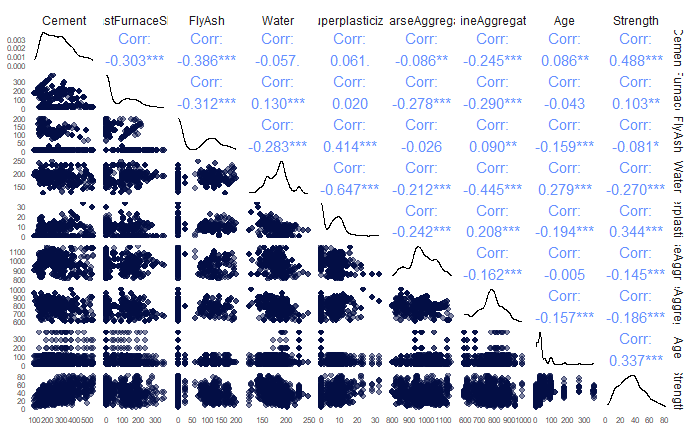

```r
library(ggplot2)
ggpairs(concrete_data,
        columns = 1:9,
        lower = list(continuous = wrap("points", alpha = 0.5, size = 1.8, color = "#030e45")),
        upper = list(continuous = wrap("cor", size = 4, color = "#648fff", display_grid = FALSE)),
        axisLabels = "show") +
  theme_minimal() +
  theme(panel.grid.major = element_blank(),
        panel.grid.minor = element_blank(),
        plot.title = element_text(hjust = 0.5, size = 6, face = "bold"),
        axis.text = element_text(size = 6))
```

At first glance it is easy to extract the following correlation: - positive correlation between **Cement** and **Strength** - positive correlation between **Strength** and **Age** - positive correlation between **Strength** and **Superplasticizer** - Negative correlation between **Water** and **Superplasticizer** - Negative correlation between **Water** and **FineAggregate**

Compute a correlation matrix for better visualization:

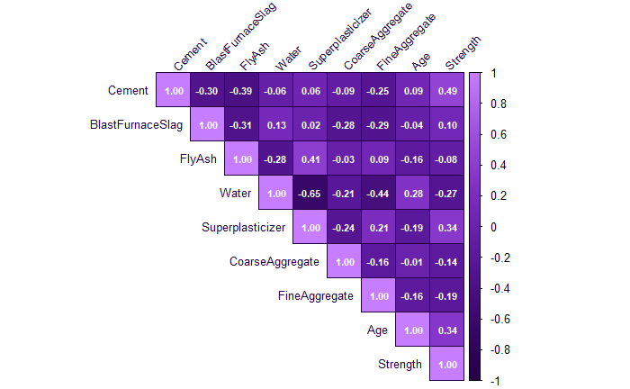

```r
cor_matrix <- cor(concrete_data)
corrplot::corrplot(cor_matrix,
                   method = "color",
                   type = "upper",
                   tl.cex = 0.8,
                   number.cex = 0.7,
                   addCoef.col = "white",
                   tl.col = "#240046",
                   number.digits = 2,
                   col = colorRampPalette(c("#240046", "#3c096c", "#5a189a","#7b2cbf","#9d4edd","#c77dff"))(200),
                   bg = "white",
                   outline = "#240046",
                   tl.srt = 45,
                   cl.cex = 0.8,
                   cl.align.text = "l")
```

Check the correlation between **Age** and **Strength**:

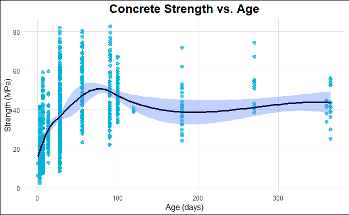

```r
ggplot(concrete_data, aes(x = Age, y = Strength)) +
  geom_point(alpha = 0.7, size = 2.5, color = "#00b4d8") +  # Enhanced points
  geom_smooth(method = "loess", color = "#030e45", fill = "#648fff", alpha = 0.4, linewidth = 1.2) + # Enhanced smooth line
  labs(title = "Concrete Strength vs. Age",
       x = "Age (days)",
       y = "Strength (MPa)") +
  theme_minimal() +
  theme(plot.title = element_text(hjust = 0.5, size = 18, face = "bold"),
        axis.title = element_text(size = 12),
        axis.text = element_text(size = 10),
        panel.grid.major = element_line(color = "#e0e0e0", linewidth = 0.2),
        panel.grid.minor = element_blank(),
        plot.background = element_rect(fill = "white"))
```

Visually it looks like the relationship is not perfectly linear.

# 4.Machine Learning Models

## Question 1: Can we predict the strength based on other variables? -> **Regression**

```r
# Split data into training and testing sets
set.seed(123)  # For reproducibility
train_indices <- sample(seq_len(nrow(concrete_data)), size = 0.8 * nrow(concrete_data))
train_data <- concrete_data[train_indices, ]
test_data <- concrete_data[-train_indices, ]
```

### Linear Regression

```r
linear_model <- lm(Strength ~ ., data = train_data)
summary(linear_model)
```

```
Call:
lm(formula = Strength ~ ., data = train_data)

Residuals:
    Min      1Q  Median      3Q     Max
-29.458  -6.639   0.780   6.358  36.727

Coefficients:
                  Estimate Std. Error t value Pr(>|t|)
(Intercept)       9.125789  28.489906   0.320  0.74881
Cement            0.107677   0.009047  11.901  < 2e-16 ***
BlastFurnaceSlag  0.087130   0.010908   7.988 4.81e-15 ***
FlyAsh            0.073166   0.013344   5.483 5.62e-08 ***
Water            -0.172546   0.043251  -3.989 7.24e-05 ***
Superplasticizer  0.296801   0.102101   2.907  0.00375 **
CoarseAggregate   0.003239   0.010163   0.319  0.75001
FineAggregate     0.008596   0.011440   0.751  0.45265
Age               0.115988   0.006097  19.023  < 2e-16 ***
---
Signif. codes:  0 ‘***’ 0.001 ‘**’ 0.01 ‘*’ 0.05 ‘.’ 0.1 ‘ ’ 1

Residual standard error: 10.07 on 795 degrees of freedom
Multiple R-squared:  0.6049,    Adjusted R-squared:  0.6009
F-statistic: 152.1 on 8 and 795 DF,  p-value: < 2.2e-16
```

```r
linear_predictions <- predict(linear_model, newdata = test_data)
print(paste("Linear Regression RMSE:", RMSE(linear_predictions, test_data$Strength)))
```

```
[1] "Linear Regression RMSE: 11.2483168055637"
```

```r
r2_lr_model <- cor(test_data$Strength, linear_predictions)^2
print(paste("Linear Regression RMSE R²:", round(r2_lr_model, 3)))
```

```
[1] "Linear Regression RMSE R²: 0.595"
```

The model performs mediocre with an R2 of 0.595. Create visualization to check the deviations between actual data and the fit.

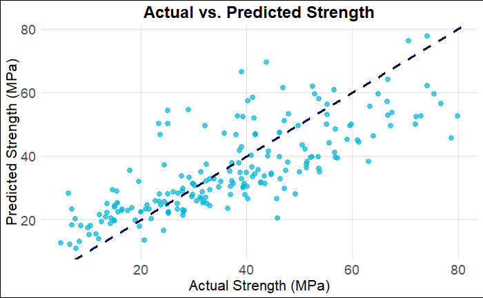

```r
ggplot(test_data, aes(x = Strength, y = linear_predictions)) +
  geom_point(alpha = 0.7, size = 2.5, color = "#00b4d8") +  # Enhanced points
  geom_abline(intercept = 0, slope = 1, color = "#030e45", linewidth = 1.2, linetype = "dashed") + # Enhanced abline
  labs(title = "Actual vs. Predicted Strength",
       x = "Actual Strength (MPa)",
       y = "Predicted Strength (MPa)") +
  theme_minimal() +
  theme(plot.title = element_text(hjust = 0.5, size = 18, face = "bold"),
        axis.title = element_text(size = 16),
        axis.text = element_text(size = 14),
        panel.grid.major = element_line(color = "#e0e0e0", linewidth = 0.2),
        panel.grid.minor = element_blank(),
        plot.background = element_rect(fill = "white"))
```

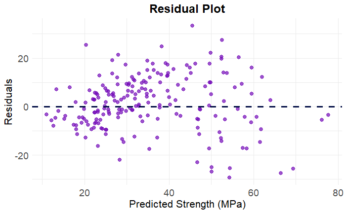

```r
# Compute residuals
residuals <- test_data$Strength - predict(linear_model, newdata = test_data)

# Create residual plot
ggplot(data.frame(Predicted = predict(linear_model, newdata = test_data), Residuals = residuals),
       aes(x = Predicted, y = Residuals)) +
  geom_point(alpha = 0.7, color = "#7209b7", size = 2.5) +
  geom_hline(yintercept = 0, color = "#030e45", linetype = "dashed",linewidth = 1.2,) +
  labs(title = "Residual Plot", x = "Predicted Strength (MPa)", y = "Residuals") +
  theme_minimal() +
  theme(plot.title = element_text(hjust = 0.5, size = 18, face = "bold"),
        axis.title = element_text(size = 16),
        axis.text = element_text(size = 14))
```

It is apparent that the model doesn’t perform perfectly. Try other.

### Random Forest Regression

```r
rf_model_reg <- randomForest(Strength ~ ., data = train_data)
rf_predictions_reg <- predict(rf_model_reg, newdata = test_data)
print(paste("Random Forest RMSE:", RMSE(rf_predictions_reg, test_data$Strength)))
```

```
[1] "Random Forest RMSE: 5.95029906710797"
```

```r
r2_rf_model <- cor(test_data$Strength, rf_predictions_reg)^2
print(paste("Random Forest R²:", round(r2_rf_model, 3)))
```

```
[1] "Random Forest R²: 0.916"
```

Random Forest performs much better with an R2 of 0.916.

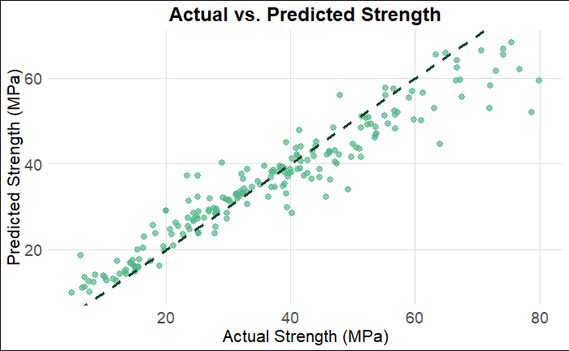

```r
ggplot(test_data, aes(x = Strength, y = rf_predictions_reg)) +
  geom_point(alpha = 0.7, size = 2.5, color = "#52b788") +  # Enhanced points
  geom_abline(intercept = 0, slope = 1, color = "#1b4332", linewidth = 1.2, linetype = "dashed") + # Enhanced abline
  labs(title = "Actual vs. Predicted Strength",
       x = "Actual Strength (MPa)",
       y = "Predicted Strength (MPa)") +
  theme_minimal() +
  theme(plot.title = element_text(hjust = 0.5, size = 18, face = "bold"),
        axis.title = element_text(size = 16),
        axis.text = element_text(size = 14),
        panel.grid.major = element_line(color = "#e0e0e0", linewidth = 0.2),
        panel.grid.minor = element_blank(),
        plot.background = element_rect(fill = "white"))
```

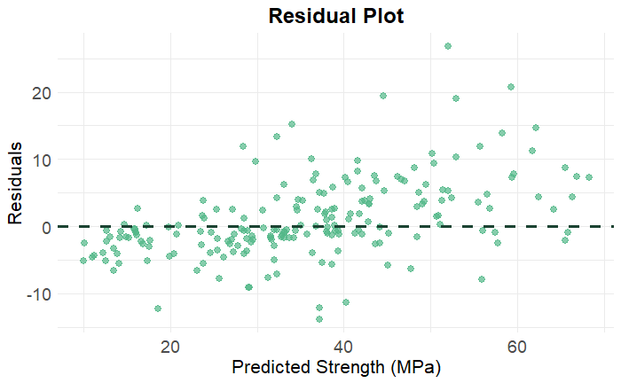

```r
residuals_rf <- test_data$Strength - predict(rf_model_reg, newdata = test_data)

# Create residual plot
ggplot(data.frame(Predicted = predict(rf_model_reg, newdata = test_data), Residuals = residuals_rf),
       aes(x = Predicted, y = Residuals)) +
  geom_point(alpha = 0.7, color = "#52b788", size = 2.5) +
  geom_hline(yintercept = 0, color = "#1b4332", linetype = "dashed",linewidth = 1.2,) +
  labs(title = "Residual Plot", x = "Predicted Strength (MPa)", y = "Residuals") +
  theme_minimal() +
  theme(plot.title = element_text(hjust = 0.5, size = 18, face = "bold"),
        axis.title = element_text(size = 16),
        axis.text = element_text(size = 14))
```

###Gradient Boosting Regression

```r
gbm_model_reg <- gbm(Strength ~ ., data = train_data, distribution = "gaussian", n.trees = 100, interaction.depth = 3, shrinkage = 0.1)
gbm_predictions_reg <- predict(gbm_model_reg, newdata = test_data, n.trees = 100)
print(paste("GBM RMSE:", RMSE(gbm_predictions_reg, test_data$Strength)))
```

```
[1] "GBM RMSE: 6.00421068467653"
```

```r
r2_gbm_model <- cor(test_data$Strength, gbm_predictions_reg)^2
print(paste("Random Forest R²:", round(r2_gbm_model, 3)))
```

```
[1] "Random Forest R²: 0.888"
```

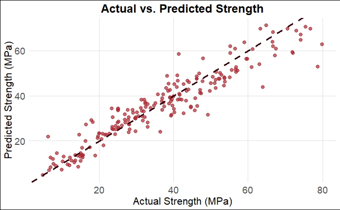

```r
ggplot(test_data, aes(x = Strength, y = gbm_predictions_reg)) +
  geom_point(alpha = 0.7, size = 2.5, color = "#ad2831") +  # Enhanced points
  geom_abline(intercept = 0, slope = 1, color = "#38040e", linewidth = 1.2, linetype = "dashed") + # Enhanced abline
  labs(title = "Actual vs. Predicted Strength",
       x = "Actual Strength (MPa)",
       y = "Predicted Strength (MPa)") +
  theme_minimal() +
  theme(plot.title = element_text(hjust = 0.5, size = 18, face = "bold"),
        axis.title = element_text(size = 16),
        axis.text = element_text(size = 14),
        panel.grid.major = element_line(color = "#e0e0e0", linewidth = 0.2),
        panel.grid.minor = element_blank(),
        plot.background = element_rect(fill = "white"))
```

Given the three tested models, **Random Forest** performed best and will be used further. However, for other data it might be wise to test also other regression models.

### Feature Importance Analysis

```r
importance(rf_model_reg)
```

```
                 IncNodePurity
Cement               40626.418
BlastFurnaceSlag     12697.932
FlyAsh                8611.908
Water                24429.996
Superplasticizer     16467.638
CoarseAggregate      13947.501
FineAggregate        14298.271
Age                  61281.640
```

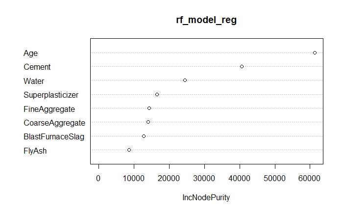

```r
varImpPlot(rf_model_reg)
```

**Age**, **Cement** and **Water** have the most significant effect on the outcome of the model.

### Model Optimization

```
mtry = 2  OOB error = 36.16556
Searching left ...
Searching right ...
mtry = 3    OOB error = 31.56298
0.127264 0.01
mtry = 4    OOB error = 28.47228
0.09792177 0.01
mtry = 6    OOB error = 29.64826
-0.04130272 0.01
```

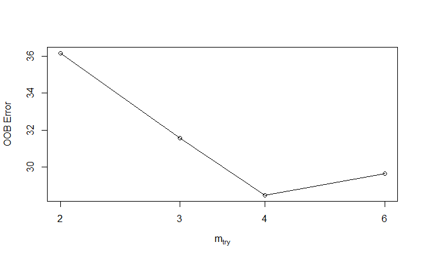

```r
# Tuning Random Forest Hyperparameters
set.seed(123)
best_mtry <- tuneRF(train_data[, -9], train_data$Strength, stepFactor = 1.5, improve = 0.01, trace = TRUE)
```

```r
set.seed(123)
rf_model <- randomForest(Strength ~ .,
                         data = train_data,
                         mtry = 4,
                         ntree = 2000,
                         nodesize = 3,
                         importance = TRUE)
```

Given the **tuneRF** function and the output of a minimum mtry value of 4, the randomForest model will be trained with the optimized parameters.

```r
# Predictions on the test set
predictions_rf <- predict(rf_model, newdata = test_data)

# Compute R² and RMSE
r2_rf <- cor(test_data$Strength, predictions_rf)^2
rmse_rf <- sqrt(mean((predictions_rf - test_data$Strength)^2))


print(paste("Optimized Random Forest R²:", round(r2_rf, 3)))
```

```
[1] "Optimized Random Forest R²: 0.923"
```

```r
print(paste("Optimized Random Forest RMSE:", round(rmse_rf, 3)))
```

```
[1] "Optimized Random Forest RMSE: 5.219"
```

```r
print(paste("Random Forest RMSE:", RMSE(rf_predictions_reg, test_data$Strength)))
```

```
[1] "Random Forest RMSE: 5.95029906710797"
```

```r
print(paste("Random Forest R²:", round(r2_rf_model, 3)))
```

```
[1] "Random Forest R²: 0.916"
```

**Hyperparameter Tuning** has helped to improve the accuracy of the model.

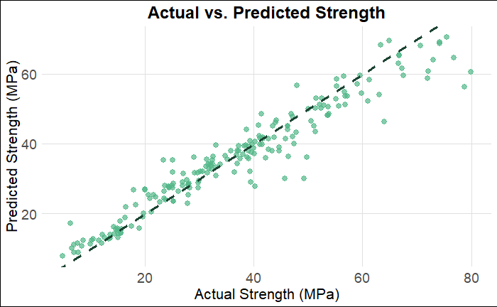

```r
ggplot(test_data, aes(x = Strength, y = predictions_rf)) +
  geom_point(alpha = 0.7, size = 2.5, color = "#52b788") +
  geom_abline(intercept = 0, slope = 1, color = "#1b4332", linewidth = 1.2, linetype = "dashed") +
  labs(title = "Actual vs. Predicted Strength",
       x = "Actual Strength (MPa)",
       y = "Predicted Strength (MPa)") +
  theme_minimal() +
  theme(plot.title = element_text(hjust = 0.5, size = 18, face = "bold"),
        axis.title = element_text(size = 16),
        axis.text = element_text(size = 14),
        panel.grid.major = element_line(color = "#e0e0e0", linewidth = 0.2),
        panel.grid.minor = element_blank(),
        plot.background = element_rect(fill = "white"))
```

## Question 2: How do different material compositions (e.g., Cement vs. Fly Ash vs. Blast Furnace Slag) interact to influence strength?

```r
rf_model <- randomForest(Strength ~ ., data = train_data, importance = TRUE)
importance(rf_model)
```

```
                   %IncMSE IncNodePurity
Cement            53.35958     41406.144
BlastFurnaceSlag  34.50004     12576.210
FlyAsh            25.00064      9269.421
Water             34.27794     22865.809
Superplasticizer  32.54307     16288.133
CoarseAggregate   28.44701     13731.216
FineAggregate     35.83998     14059.255
Age              103.14904     61387.052
```

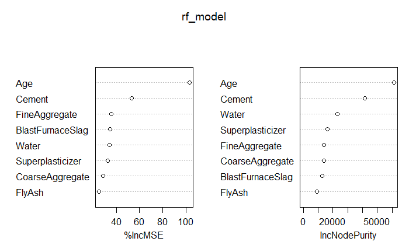

```r
varImpPlot(rf_model)
```

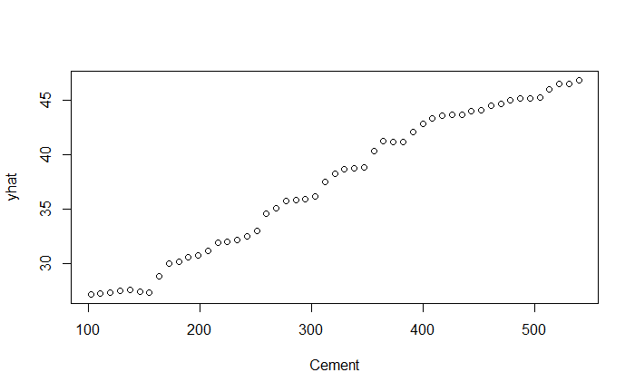

```r
library(pdp)
# Partial dependence of Cement
cement_pdp <- partial(rf_model, pred.var = "Cement")
plot(cement_pdp)
```

**Increasing** the Cement content generally leads to increased *Strength*.

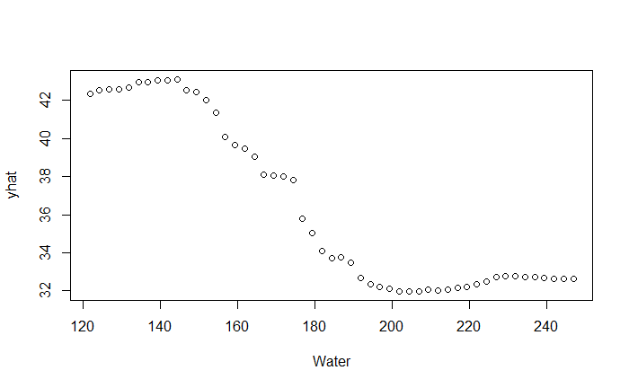

```r
#Partial dependence of Water
Water_pdp <- partial(rf_model, pred.var = "Water")
plot(Water_pdp)
```

**Water content** should be reduced.

Check for partial dependence of water and cement.

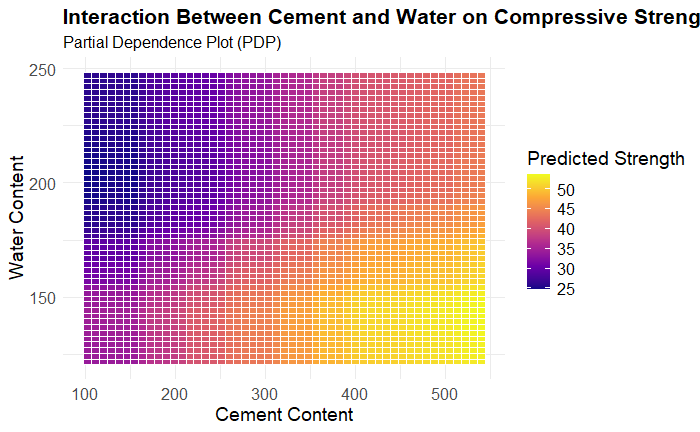

```r
interaction_pdp <- partial(rf_model, pred.var = c("Cement", "Water"))
ggplot(interaction_pdp, aes(x = Cement, y = Water, z = yhat)) +
  geom_tile(aes(fill = yhat), color = "white") +
  scale_fill_viridis_c(option = "C") +
  labs(title = "Interaction Between Cement and Water on Compressive Strength",
       subtitle = "Partial Dependence Plot (PDP)",
       x = "Cement Content",
       y = "Water Content",
       fill = "Predicted Strength") +
  theme_minimal() +
  theme(
    text = element_text(size = 12),
    plot.title = element_text(size = 16, face = "bold"),
    plot.subtitle = element_text(size = 12),
    axis.title = element_text(size = 14),
    axis.text = element_text(size = 12),
    legend.title = element_text(size = 14),
    legend.text = element_text(size = 12)
  ) +
  theme(legend.position = "right")
```

Check for partial dependence of Age and cement.

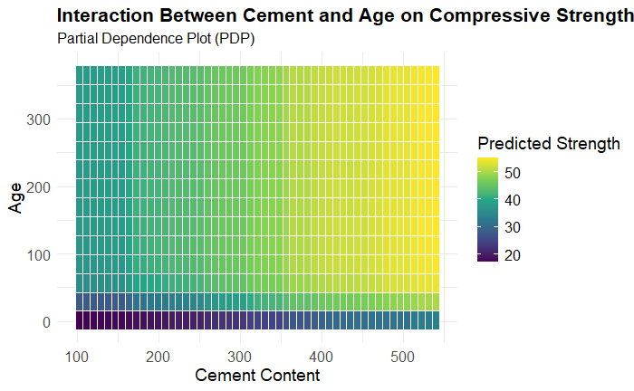

## Question 3: How much does a Suplerplasticizer help? At what point does adding Superplasticizer not help anymore?

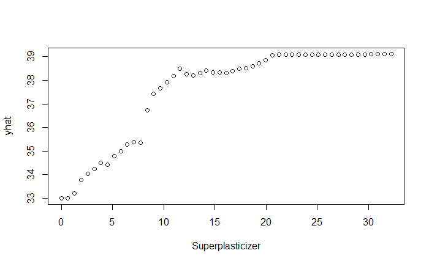

```r
superplasticizer_pdp <- partial(rf_model, pred.var = "Superplasticizer")
plot(superplasticizer_pdp)
```

```r
range(concrete_data$Superplasticizer)
```

```
[1]  0.0 32.2
```

```r
min_strength <- superplasticizer_pdp$yhat[which.min(superplasticizer_pdp$Superplasticizer)]
max_strength <- superplasticizer_pdp$yhat[which.max(superplasticizer_pdp$Superplasticizer)]

# Calculate the difference
strength_increase <- max_strength - min_strength
print(paste("Strength increase due to superplasticizer:", strength_increase))
```

```
[1] "Strength increase due to superplasticizer: 6.12375391313104"
```

[figure not shown]

```r
interaction_pdp <- partial(rf_model, pred.var = c("Water", "Superplasticizer"))
ggplot(interaction_pdp, aes(x = Water, y = Superplasticizer, z = yhat)) +
  geom_tile(aes(fill = yhat), color = "white") +
  scale_fill_viridis_c(option = "plasma") +
  labs(title = "Interaction Between Cement and Age on Compressive Strength",
       subtitle = "Partial Dependence Plot (PDP)",
       x = "Water Content",
       y = "Superplasticizer",
       fill = "Predicted Strength") +
  theme_minimal() +
  theme(
    text = element_text(size = 12),
    plot.title = element_text(size = 16, face = "bold"),
    plot.subtitle = element_text(size = 12),
    axis.title = element_text(size = 14),
    axis.text = element_text(size = 12),
    legend.title = element_text(size = 14),
    legend.text = element_text(size = 12)
  ) +
  theme(legend.position = "right")
```

Given the visualizations from above the water content can be kept minimum when using a superplasticizer. However, the use of the superplasticizer can be limited to ~ 15(component 5)(kg in a m^3 mixture) to achieve a high strength.